# Plotting Composite Material Data

Ally Fraser

2-May-2020

This vignette demonstrates how to create some of the graphs commonly used when analyzing composite material data. Here, we rely on the [`ggplot2`](https://ggplot2.tidyverse.org/) package for graphing. This package can be loaded either on its own, or through the `tidyverse` meta-package, which also includes packages such as `dplyr` that we will also use.

We’ll need to load a few packages in order to proceed.

```r
library(dplyr)
library(ggplot2)
library(tidyr)
library(cmstatr)
```

Throughout this vignette, we’ll use one of the example data sets that comes with `cmstatr` and we’ll focus on the warp-tension data as an example. We’ll load the example data in a variable as follows. By default the condition will be in an arbitrary order, but throughout the visualization, we’ll want the conditions shown in a particular order (from coldest and driest to hottest and wettest). We can define the order of the conditions using the `ordered` function. For brevity, only the first few rows of the data set are displayed below.

```r
dat <- carbon.fabric.2 %>%
  filter(test == "WT") %>%
  mutate(condition = ordered(condition, c("CTD", "RTD", "ETW", "ETW2")))

dat %>%
  head(10)
```

```
#>    test condition batch panel thickness nplies strength modulus failure_mode
#> 1    WT       CTD     A     1     0.112     14  142.817   9.285          LAT
#> 2    WT       CTD     A     1     0.113     14  135.901   9.133          LAT
#> 3    WT       CTD     A     1     0.113     14  132.511   9.253          LAT
#> 4    WT       CTD     A     2     0.112     14  135.586   9.150          LAB
#> 5    WT       CTD     A     2     0.113     14  125.145   9.270          LAB
#> 6    WT       CTD     A     2     0.113     14  135.203   9.189          LGM
#> 7    WT       CTD     A     2     0.113     14  128.547   9.088          LAB
#> 8    WT       CTD     B     1     0.113     14  127.709   9.199          LGM
#> 9    WT       CTD     B     1     0.113     14  127.074   9.058          LGM
#> 10   WT       CTD     B     1     0.114     14  126.879   9.306          LGM
```

```r
b_basis_pooled <- dat %>%
  basis_pooled_cv(strength, condition, batch,
                  override = c("between_group_variability",
                               "normalized_variance_equal"))

b_basis_pooled
```

```
#>
#> Call:
#> basis_pooled_cv(data = ., x = strength, groups = condition, batch = batch,
#>     override = c("between_group_variability", "normalized_variance_equal"))
#>
#> Distribution:  Normal - Pooled CV    ( n = 86, r = 4 )
#> The following diagnostic tests were overridden:
#>     `between_group_variability`,
#>     `normalized_variance_equal`
#> B-Basis:   ( p = 0.9 , conf = 0.95 )
#> CTD   125.1325
#> RTD   129.3447
#> ETW   123.809
#> ETW2  120.3191
```

The object returned from `basis_pooled_cv` contains a number of values. One value is a `data.frame` containing the groups (i.e. conditions) and the corresponding basis values. This looks like the following. We’ll use this in the visualizations.

```r
b_basis_pooled$basis
```

```
#>      group    value
#> CTD    CTD 125.1325
#> RTD    RTD 129.3447
#> ETW    ETW 123.8090
#> ETW2  ETW2 120.3191
```

# Batch Plots

Batch plots are used to identify differences between batches. Simple batch plots can be created using box plots and adding horizontal lines for the basis values as follows. Note that the heavy line in the box of the box plot is the *median*, not the mean. The two hinges correspond with the first and third quantiles and the whiskers extend to the most extreme data point, or 1.5 times the inner quantile range.

In the code below, we use the function `rename` to rename the column `group` to `condition`. The `data.frame` produced by `basis_pooled_cv` uses the columns `value` and `group`, but to match the data, we need the column with the conditions to be named `condition`.

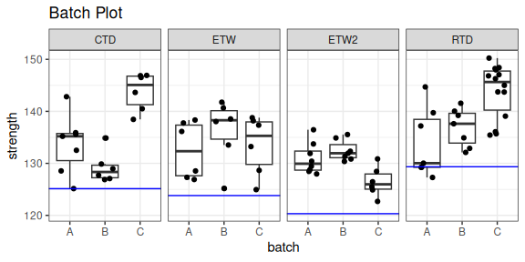

```r
dat %>%
  ggplot(aes(x = batch, y = strength)) +
  geom_boxplot() +
  geom_jitter(width = 0.25) +
  geom_hline(aes(yintercept = value),
             data = b_basis_pooled$basis %>% rename(condition = group),
             color = "blue") +
  facet_grid(. ~ condition) +
  theme_bw() +
  ggtitle("Batch Plot")
```

It’s sometimes useful add failure modes to the plot so that you can easily identify whether failure modes differ between conditions or batches. This can be done with the `geom_jitter_failure_mode()` function. This behaves very similarly to `geom_jitter()`, except that `color` or `shape` must be specified, and if there are multiple failure modes (e.g. “LAB/LAT”), both failure modes are plotted as separate points.

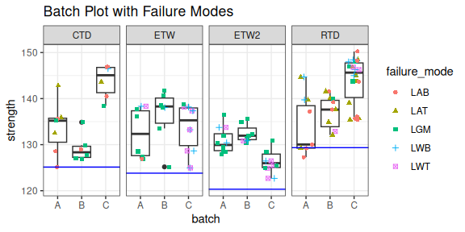

```r
dat %>%
  ggplot(aes(x = batch, y = strength)) +
  geom_boxplot() +
  geom_jitter_failure_mode(aes(color = failure_mode, shape = failure_mode), width = 0.25) +
  geom_hline(aes(yintercept = value),
             data = b_basis_pooled$basis %>% rename(condition = group),
             color = "blue") +
  facet_grid(. ~ condition) +
  theme_bw() +
  ggtitle("Batch Plot with Failure Modes")
```

# Quantile Plots

A quantile plot provides a graphical summary of sample values. This plot displays the sample values and the corresponding quantile. A quantile plot can be used to examine the symmetry and tail sizes of the underlying distribution. Sharp rises may indicate the presence of outliers.

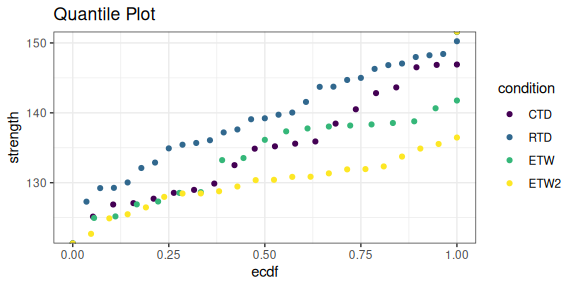

```r
dat %>%
  ggplot(aes(x = strength, color = condition)) +
  stat_ecdf(geom = "point") +
  coord_flip() +
  theme_bw() +
  ggtitle("Quantile Plot")
```

# Normal Survival Function Plots

An empirical survival function, and the corresponding normal survival function can be plotted using two `ggplot` “stat” functions provided by `cmstatr`. In the example below, the empirical survival function is plotted for each condition, and the survival function for a normal distribution with the mean and variance from the data is also plotted (the survival function is 1 minus the cumulative distribution function). This type of plot can be used to identify how closely the data follows a normal distribution, and also to compare the distributions of the various conditions.

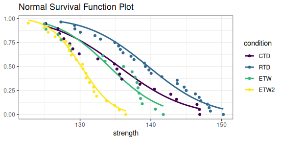

```r
dat %>%
  ggplot(aes(x = strength, color = condition)) +
  stat_normal_surv_func() +
  stat_esf() +
  theme_bw() +
  ggtitle("Normal Survival Function Plot")
```

# Normal Score Plots

The normal scores plot calculates the normal score and plots it against the normal score. Normal plots are useful to investigate distributions of the data.

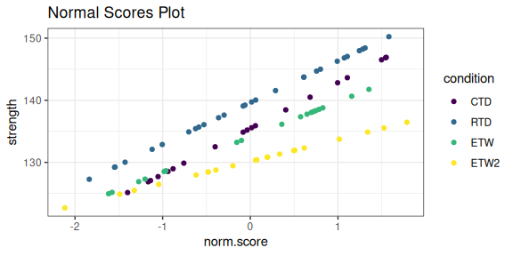

```r
dat %>%
  group_by(condition) %>%
  mutate(norm.score = scale(strength)) %>%
  ggplot(aes(x = norm.score, y = strength, colour = condition)) +
  geom_point() +
  ggtitle("Normal Scores Plot") +
  theme_bw()
```

# Q-Q Plots

A Q-Q plot compares the data against the theoretical quantiles for a particular distribution. A line is also plotted showing the normal distribution with mean and variance from the data. If the data exactly followed a normal distribution, all points would fall on this line.

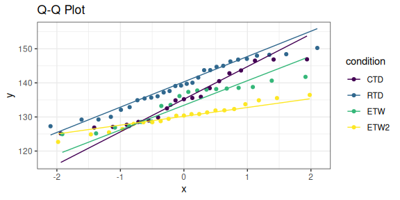

```r
dat %>%
  ggplot(aes(sample = strength, colour = condition)) +
  geom_qq() +
  geom_qq_line() +
  ggtitle("Q-Q Plot") +
  theme_bw()
```

# Property Plots

Property plots allow for a variety of properties for a group to be compared to other properties within the same group, as well as to other group properties. The properties included in this plot are A-Basis, B-Basis, Pooled A- and B-Basis, Pooled Modified CV (Coefficient of Variation) A- and B-Basis, Mean, and Min for each group.

The property plots will take a bit of work to construct.

First, the distribution of each group must be determined. Once the distribution has been determined, the proper basis calculation based on that distribution should be filled in below. We also have a column in the tables below for extra arguments to pass to the `basis` function, such as overrides required or the method for the `basis_hk_ext` function to use.

```r
b_basis_fcn <- tribble(
  ~condition, ~fcn, ~args,
  "CTD", "basis_normal", list(override = c("between_batch_variability")),
  "RTD", "basis_normal", list(override = c("between_batch_variability")),
  "ETW", "basis_hk_ext", NULL,
  "ETW2", "basis_normal", list(override = c("between_batch_variability"))
)

a_basis_fcn <- tribble(
  ~condition, ~fcn, ~args,
  "CTD", "basis_normal", list(override = c("between_batch_variability")),
  "RTD", "basis_normal", list(override = c("between_batch_variability")),
  "ETW", "basis_hk_ext", list(method = "woodward-frawley"),
  "ETW2", "basis_normal", list(override = c("between_batch_variability"))
)
```

We’ll write a function that takes the data and information about the distribution and computes the single-point basis value. We’ll use this function for both A- and B-Basis, so we’ll add a parameter for the probability (0.90 or 0.99).

```r
single_point_fcn <- function(group_x, group_batch, cond, basis_fcn, p) {
  fcn <- basis_fcn$fcn[basis_fcn$condition == cond[1]]
  extra_args <- basis_fcn$args[basis_fcn$condition == cond[1]]

  args <- c(
    list(x = group_x, batch = group_batch, p = p),
    unlist(extra_args))
  basis <- do.call(fcn, args)
  basis$basis
}

single_point_results <- dat %>%
  group_by(condition) %>%
  summarise(single_point_b_basis = single_point_fcn(
              strength, batch, condition, b_basis_fcn, 0.90),
            single_point_a_basis = single_point_fcn(
              strength, batch, condition, a_basis_fcn, 0.99),
            minimum = min(strength),
            mean = mean(strength)) %>%
  mutate(condition = ordered(condition, c("CTD", "RTD", "ETW", "ETW2")))

single_point_results
```

```
#> # A tibble: 4 × 5
#>   condition single_point_b_basis single_point_a_basis minimum  mean
#>   <ord>                    <dbl>                <dbl>   <dbl> <dbl>
#> 1 CTD                       121.                 111.    125.  135.
#> 2 RTD                       128.                 119.    127.  140.
#> 3 ETW                       121.                 103.    125.  134.
#> 4 ETW2                      123.                 119.    123.  130.
```

In the above code, we also ensure that the condition column is still in the order we expect.

We’ve already computed the B-Basis of the data using a pooling method. We’ll do the same for A-Basis:

```r
a_basis_pooled <- dat %>%
  basis_pooled_cv(strength, condition, batch, p = 0.99,
                  override = c("between_group_variability",
                               "normalized_variance_equal"))

a_basis_pooled
```

```
#>
#> Call:
#> basis_pooled_cv(data = ., x = strength, groups = condition, batch = batch,
#>     p = 0.99, override = c("between_group_variability", "normalized_variance_equal"))
#>
#> Distribution:  Normal - Pooled CV    ( n = 86, r = 4 )
#> The following diagnostic tests were overridden:
#>     `between_group_variability`,
#>     `normalized_variance_equal`
#> A-Basis:   ( p = 0.99 , conf = 0.95 )
#> CTD   118.3205
#> RTD   122.2636
#> ETW   117.074
#> ETW2  113.7601
```

As we saw before, the returned object has a property called `basis`, which is a `data.frame` for the pooling methods.

```r
a_basis_pooled$basis
```

```
#>      group    value
#> CTD    CTD 118.3205
#> RTD    RTD 122.2636
#> ETW    ETW 117.0740
#> ETW2  ETW2 113.7601
```

We can take this `data.frame` and change the column names to suit our needs.

```r
a_basis_pooled$basis %>%
  rename(condition = group,
         b_basis_pooled = value)
```

```
#>      condition b_basis_pooled
#> CTD        CTD       118.3205
#> RTD        RTD       122.2636
#> ETW        ETW       117.0740
#> ETW2      ETW2       113.7601
```

We can combine all these steps into one statement. We’ll also ensure that the conditions are listed in the order we want.

```r
a_basis_pooled_results <- a_basis_pooled$basis %>%
  rename(condition = group,
         a_basis_pooled = value) %>%
  mutate(condition = ordered(condition, c("CTD", "RTD", "ETW", "ETW2")))

a_basis_pooled_results
```

```
#>      condition a_basis_pooled
#> CTD        CTD       118.3205
#> RTD        RTD       122.2636
#> ETW        ETW       117.0740
#> ETW2      ETW2       113.7601
```

And the same thing for B-Basis:

```r
b_basis_pooled_results <- b_basis_pooled$basis %>%
  rename(condition = group,
         b_basis_pooled = value) %>%
  mutate(condition = ordered(condition, c("CTD", "RTD", "ETW", "ETW2")))

b_basis_pooled_results
```

```
#>      condition b_basis_pooled
#> CTD        CTD       125.1325
#> RTD        RTD       129.3447
#> ETW        ETW       123.8090
#> ETW2      ETW2       120.3191
```

We can use the function `inner_join` from the `dplyr` package to combine the three sets of computational results. Each row for each condition will be concatenated.

```r
single_point_results %>%
  inner_join(b_basis_pooled_results, by = "condition") %>%
  inner_join(a_basis_pooled_results, by = "condition")
```

```
#> # A tibble: 4 × 7
#>   condition single_point_b_basis single_point_a_basis minimum  mean
#>   <ord>                    <dbl>                <dbl>   <dbl> <dbl>
#> 1 CTD                       121.                 111.    125.  135.
#> 2 RTD                       128.                 119.    127.  140.
#> 3 ETW                       121.                 103.    125.  134.
#> 4 ETW2                      123.                 119.    123.  130.
#> # ℹ 2 more variables: b_basis_pooled <dbl>, a_basis_pooled <dbl>
```

To use this table in the plot we’re trying to construct, we want to “lengthen” the table as follows.

```r
single_point_results %>%
  inner_join(b_basis_pooled_results, by = "condition") %>%
  inner_join(a_basis_pooled_results, by = "condition") %>%
  pivot_longer(cols = single_point_b_basis:a_basis_pooled)
```

```
#> # A tibble: 24 × 3
#>    condition name                 value
#>    <ord>     <chr>                <dbl>
#>  1 CTD       single_point_b_basis  121.
#>  2 CTD       single_point_a_basis  111.
#>  3 CTD       minimum               125.
#>  4 CTD       mean                  135.
#>  5 CTD       b_basis_pooled        125.
#>  6 CTD       a_basis_pooled        118.
#>  7 RTD       single_point_b_basis  128.
#>  8 RTD       single_point_a_basis  119.
#>  9 RTD       minimum               127.
#> 10 RTD       mean                  140.
#> # ℹ 14 more rows
```

We can now make a plot based on this:

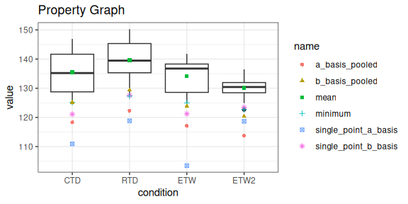

```r
single_point_results %>%
  inner_join(b_basis_pooled_results, by = "condition") %>%
  inner_join(a_basis_pooled_results, by = "condition") %>%
  pivot_longer(cols = single_point_b_basis:a_basis_pooled) %>%
  ggplot(aes(x = condition, y = value)) +
  geom_boxplot(aes(y = strength), data = dat) +
  geom_point(aes(shape = name, color = name)) +
  ggtitle("Property Graph") +
  theme_bw()
```

# Nested Data Plots

`cmstatr` contains the function `nested_data_plot`. This function creates a plot showing the sources of variation. In the following example, the data is grouped according to the variables in the `group` argument. The data is first grouped according to `batch`, then according to `panel`. The labels located according to the data points that fall under them. By default, the mean is used, but that `stat` argument can be used to locate the labels according to `median` or some other statistic.

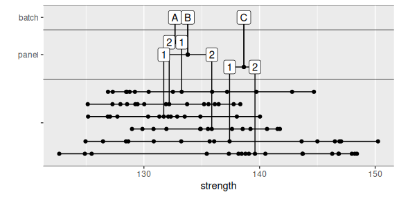

```r
carbon.fabric.2 %>%
  mutate(panel = as.character(panel)) %>%
  filter(test == "WT") %>%
  nested_data_plot(strength,
                   groups = c(batch, panel))
```

Optionally, `fill` or `color` can be set as follows:

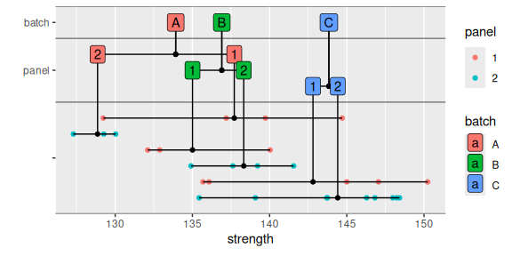

```r
carbon.fabric.2 %>%
  mutate(panel = as.character(panel)) %>%
  filter(test == "WT" & condition == "RTD") %>%
  nested_data_plot(strength,
                   groups = c(batch, panel),
                   fill = batch,
                   color = panel)
```